# R Notebook

# Clasificación

## Práctico 3a

Diploma Universitario en Ciencias Sociales Computacionales y Humanidades Digitales (UNSAM).

Módulo 3: Introducción al modelado de datos.

## El set de datos ‘Stock Market’

Vamos a utilizar el dataset **Smarket**, el cual consiste en los retornos porcentuales del índice de acciones S&P 500 a lo largo de 1250 días, desde el inicio de 2001 hasta el 2005. Para cada fecha, tenemos registrado el retorno porcentual de cada uno de los 5 días previos (**Lag1**:**Lag5**), también está registrado el volumen (**Volume**) operado en el día previo, expresado en billones. **Today** contiene el retorno porcentual para la fecha en cuestión y **Direction** la dirección del mercado (si estuvo alcista o **Up** o bajista **Down**).

```r
install.packages("ISLR")
```

```r
library(ISLR)
names(Smarket)
```

```
[1] "Year"      "Lag1"      "Lag2"      "Lag3"      "Lag4"      "Lag5"      "Volume"    "Today"     "Direction"
```

```r
dim(Smarket)
```

```
[1] 1250    9
```

```r
summary(Smarket)
```

```
      Year           Lag1                Lag2                Lag3                Lag4                Lag5              Volume
 Min.   :2001   Min.   :-4.922000   Min.   :-4.922000   Min.   :-4.922000   Min.   :-4.922000   Min.   :-4.92200   Min.   :0.3561
 1st Qu.:2002   1st Qu.:-0.639500   1st Qu.:-0.639500   1st Qu.:-0.640000   1st Qu.:-0.640000   1st Qu.:-0.64000   1st Qu.:1.2574
 Median :2003   Median : 0.039000   Median : 0.039000   Median : 0.038500   Median : 0.038500   Median : 0.03850   Median :1.4229
 Mean   :2003   Mean   : 0.003834   Mean   : 0.003919   Mean   : 0.001716   Mean   : 0.001636   Mean   : 0.00561   Mean   :1.4783
 3rd Qu.:2004   3rd Qu.: 0.596750   3rd Qu.: 0.596750   3rd Qu.: 0.596750   3rd Qu.: 0.596750   3rd Qu.: 0.59700   3rd Qu.:1.6417
 Max.   :2005   Max.   : 5.733000   Max.   : 5.733000   Max.   : 5.733000   Max.   : 5.733000   Max.   : 5.73300   Max.   :3.1525
     Today           Direction
 Min.   :-4.922000   Down:602
 1st Qu.:-0.639500   Up  :648
 Median : 0.038500
 Mean   : 0.003138
 3rd Qu.: 0.596750
 Max.   : 5.733000
```

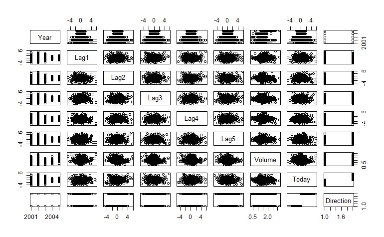

```r
pairs(Smarket)
```

Usemos **cor()** para generar una matriz que contenga la comparación de las correlaciones en los predictores del set de datos. Debemos dejar afuera **Direction** ya que es cualitativa.

```r
cor(Smarket[,-9])
```

```
             Year         Lag1         Lag2         Lag3         Lag4         Lag5      Volume        Today
Year   1.00000000  0.029699649  0.030596422  0.033194581  0.035688718  0.029787995  0.53900647  0.030095229
Lag1   0.02969965  1.000000000 -0.026294328 -0.010803402 -0.002985911 -0.005674606  0.04090991 -0.026155045
Lag2   0.03059642 -0.026294328  1.000000000 -0.025896670 -0.010853533 -0.003557949 -0.04338321 -0.010250033
Lag3   0.03319458 -0.010803402 -0.025896670  1.000000000 -0.024051036 -0.018808338 -0.04182369 -0.002447647
Lag4   0.03568872 -0.002985911 -0.010853533 -0.024051036  1.000000000 -0.027083641 -0.04841425 -0.006899527
Lag5   0.02978799 -0.005674606 -0.003557949 -0.018808338 -0.027083641  1.000000000 -0.02200231 -0.034860083
Volume 0.53900647  0.040909908 -0.043383215 -0.041823686 -0.048414246 -0.022002315  1.00000000  0.014591823
Today  0.03009523 -0.026155045 -0.010250033 -0.002447647 -0.006899527 -0.034860083  0.01459182  1.000000000
```

Como se podría esperar, la correlación entre **Today** y las variables **Lag** son cercanas a cero. En otras palabras, parece ser que existe poca correlación entre los retornos del día y los de los días previos. La única correlación sustancial que podemos ver es entre **Year** y **Volume**, ploteando los datos podemos ver que **Volume** se incrementa con el tiempo. En otras palabras, el número promedio de transacciónes se incrementó entre 2001 y 2005.

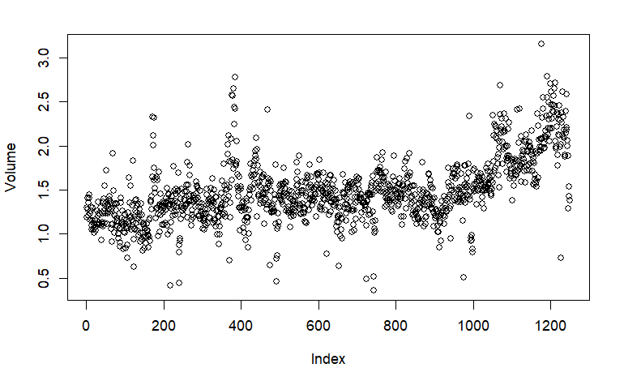

```r
attach(Smarket)
plot(Volume)
```

## Regresión logística

Ajustemos un modelo de regresión logística buscando predecir **Direction** usando **Lag1** hasta **Lag5** y **Volume**. La función **glm()** ajusta *modelos lineales generalizados* por lo que debemos especificar **family=binomial** para indicarle a *R* que deseamos generar una regresión logística.

```r
glm.fits=glm(Direction~Lag1+Lag2+Lag3+Lag4+Lag5+Volume,data=Smarket,family=binomial)
summary(glm.fits)
```

```
Call:
glm(formula = Direction ~ Lag1 + Lag2 + Lag3 + Lag4 + Lag5 +
    Volume, family = binomial, data = Smarket)

Deviance Residuals:
   Min      1Q  Median      3Q     Max
-1.446  -1.203   1.065   1.145   1.326

Coefficients:
             Estimate Std. Error z value Pr(>|z|)
(Intercept) -0.126000   0.240736  -0.523    0.601
Lag1        -0.073074   0.050167  -1.457    0.145
Lag2        -0.042301   0.050086  -0.845    0.398
Lag3         0.011085   0.049939   0.222    0.824
Lag4         0.009359   0.049974   0.187    0.851
Lag5         0.010313   0.049511   0.208    0.835
Volume       0.135441   0.158360   0.855    0.392

(Dispersion parameter for binomial family taken to be 1)

    Null deviance: 1731.2  on 1249  degrees of freedom
Residual deviance: 1727.6  on 1243  degrees of freedom
AIC: 1741.6

Number of Fisher Scoring iterations: 3
```

Bajo P-value de Lag1. El coeficiente negativo de Lag 1 sugiere que si el mercado tuvo un retorno positivo el día anterior, entonces es menos probable que el mercado se sea alcista el día presente (variable **Today**).

Sin embargo ese p-value es relativamente grande, por lo que no hay evidencia clara de una asociación real entre Lag1 y Dirección.

Indaguemos sobre los resultados usando **coef()** y **summary()**

```r
coef(glm.fits)
```

```
 (Intercept)         Lag1         Lag2         Lag3         Lag4         Lag5       Volume
-0.126000257 -0.073073746 -0.042301344  0.011085108  0.009358938  0.010313068  0.135440659
```

```r
summary(glm.fits)$coef
```

```
                Estimate Std. Error    z value  Pr(>|z|)
(Intercept) -0.126000257 0.24073574 -0.5233966 0.6006983
Lag1        -0.073073746 0.05016739 -1.4565986 0.1452272
Lag2        -0.042301344 0.05008605 -0.8445733 0.3983491
Lag3         0.011085108 0.04993854  0.2219750 0.8243333
Lag4         0.009358938 0.04997413  0.1872757 0.8514445
Lag5         0.010313068 0.04951146  0.2082966 0.8349974
Volume       0.135440659 0.15835970  0.8552723 0.3924004
```

```r
glm.probs=predict(glm.fits,type="response")
glm.probs[1:10]
```

```
        1         2         3         4         5         6         7         8         9        10
0.5070841 0.4814679 0.4811388 0.5152224 0.5107812 0.5069565 0.4926509 0.5092292 0.5176135 0.4888378
```

```r
contrasts(Direction)
```

```
     Up
Down  0
Up    1
```

Para hacer una predicción respecto a un mercado alcista o bajista, debemos convertir estas predicciones en etiquetas.

```r
glm.pred=rep("Down",1250)
glm.pred[glm.probs>.5]="Up"
```

Creamos la matriz de confusión.

```r
table(glm.pred,Direction)
```

```
        Direction
glm.pred Down  Up
    Down  145 141
    Up    457 507
```

Predecimos de manera correcta 507 observaciones respecto a un mercado alcista y 145 un mercado bajista.

```r
(507+145) / 1250
```

```
[1] 0.5216
```

El 52.2% de las veces la predicción fue correcta.Hay otra forma de acceder al mismo resultado.

```r
mean(glm.pred==Direction)
```

```
[1] 0.5216
```

100% - 52.2% = 47.8% es el ratio de error de nuestro set de entrenamiento. Pero esto es algo que debemos evitar, ya que el testeo de nuestros debemos realizarlo con el set de test y no con el set de train.

Ahora, generemos un nuevo modelo, pero usando de set de entrenamiento las observaciones que sucedieron previo al año 2005 y testeando contra las observaciones que sucedieron en 2005.

Primero vamos a crear el set de train y de test.

```r
train=(Year<2005)
Smarket.2005=Smarket[!train,]
dim(Smarket.2005)
```

```
[1] 252   9
```

```r
Direction.2005=Direction[!train]
```

El objeto **train** es un vector de 1250 elementos, que corresponden a las observaciones de nuestro data set. Los elementos del vector que corresponden a observaciones ocurridas antes de 2005, son definidas como **TRUE**, mientras que las observaciones que ocurren en 2005 figuran como **FALSE**. **train** es un vector *booleano* que será de utilidad para generar un subset del set de datos original. El comando **Smarket[!train,]** seleccionará solo el subset de datos correspondiente a observaciones realizadas en 2005.

Ahora vamos a modelizar una regresión logística usando el subset de datos que corresponden a los datos previos a 2005, usando el argumento **subset**.

```r
glm.fits=glm(Direction~Lag1+Lag2+Lag3+Lag4+Lag5+Volume,data=Smarket,family=binomial,subset=train)
```

```r
glm.probs=predict(glm.fits,Smarket.2005,type="response")
```

Finalmente computamos las predicciones para el año 2005 y los comparamos los movimientos reales del mercado para esa observación

```r
glm.pred=rep("Down",252)
glm.pred[glm.probs>.5]="Up"
table(glm.pred,Direction.2005)
```

```
        Direction.2005
glm.pred Down Up
    Down   77 97
    Up     34 44
```

```r
mean(glm.pred==Direction.2005)
```

```
[1] 0.4801587
```

```r
mean(glm.pred!=Direction.2005)
```

```
[1] 0.5198413
```

**!=** significa “no es igual a”, por lo que estamos computando el ratio de error para set de prueba. Los resultados son un poco decepcionantes, el ratio es del 52%. Recordemos que en el modelo de regresión logística tenia **p-values** poco relevantes asociados a los predictores, y que el **p-value** más bajo era el de **Lag1**. Quizá si removemos las variables que parece no estan ayudando mucho a generar predicciones precisas ayude a aumentar la efectividad del modelo. Recordemos que, si usamos predictores que no tienen relación con la variable de respuesta, esto tiende a deteriorar el ratio de error del set de prueba (dado que los predictores pueden aumentar la varianza sin que eso se corresponda con un descenso en el sesgo), por lo que remover predictores innecesarios puede aumentar la efectividad de nuestro modelo. Usemos **Lag1** y **Lag2**, variables que parecen tener el poder predictivo más alto según el modelo que generamos inicialmente.

```r
glm.fits=glm(Direction~Lag1+Lag2,data=Smarket,family =binomial,subset=train)
glm.probs=predict(glm.fits,Smarket.2005,type="response")
glm.pred=rep("Down",252)
glm.pred[glm.probs >.5]="Up"
table(glm.pred,Direction.2005)
```

```
        Direction.2005
glm.pred Down  Up
    Down   35  35
    Up     76 106
```

```r
mean(glm.pred==Direction.2005)
```

```
[1] 0.5595238
```

```r
106/(106+76)
```

```
[1] 0.5824176
```

Los resultados son apenas un poco mejores, 56% de los movimientos diarios fueron correctamente estimados. Sin embargo, los días que han sido estimados como alcistas, el modelo acertó el 58% de las veces. Esto sugiere una estrategia de trading que recomienda comprar en los días en que el modelo predice un mercado alcista, y evitar comprar en días que sean estimados como bajistas.

```r
predict(glm.fits,newdata=data.frame(Lag1=c(1.2,1.5),Lag2=c(1.1,-0.8)),type ="response")
```

```
        1         2
0.4791462 0.4960939
```

## LDA (Linear Discriminant Analysis)

Ajustemos un modelo LDA usando la libreria **MASS**. La función se llama **lda()**. Entrenemos el modelo, como en el caso anterior, con el set de datos de entrenamiento (observaciones previo a 2005).

```r
library(MASS)
lda.fit=lda(Direction~Lag1+Lag2,data=Smarket,subset=train)
lda.fit
```

```
Call:
lda(Direction ~ Lag1 + Lag2, data = Smarket, subset = train)

Prior probabilities of groups:
    Down       Up
0.491984 0.508016

Group means:
            Lag1        Lag2
Down  0.04279022  0.03389409
Up   -0.03954635 -0.03132544

Coefficients of linear discriminants:
            LD1
Lag1 -0.6420190
Lag2 -0.5135293
```

```r
lda.pred=predict(lda.fit,Smarket.2005)
names(lda.pred)
```

```
[1] "class"     "posterior" "x"
```

Realizá una matriz de confusión para evaluar cómo se desempeñó el modelo. Comparalo con la regresión logística. ¿Qué podemos decir?

```r
lda.class=lda.pred$class
table(lda.class,Direction.2005)
```

```
         Direction.2005
lda.class Down  Up
     Down   35  35
     Up     76 106
```

```r
mean(lda.class==Direction.2005)
```

```
[1] 0.5595238
```

```r
mean(lda.class!=Direction.2005)
```

```
[1] 0.4404762
```

## K-Nearest Neighbors

Usemos ahora la función **knn()**, parte de la librería **class**. La función requiere 4 intpus:

1. Una matriz que contenga los predictores asociados al set de entrenamiento, nominado **train.X** a continuación.
2. Una matriz que contenga los predictores asociados con los datos sobre los que queremos realizar predicciones, nominado **test.X**.
3. Un vector que contenga las etiquetas de clase para las observaciones del set de entrenamiento, nominado **train.Direction** a continuación.
4. Un valor para *K*, el número de vecinos próximos usado por el clasificador.

Usamos **cbind()** (abreviación de *column bind*) para unir las variables **Lag1** y **Lag2* entre ellas para generar dos matrices, una para el set de entrenamiento y otra para set de testeo.

```r
library(class)
train.X=cbind(Lag1,Lag2)[train,]
test.X=cbind(Lag1,Lag2)[!train,]
train.Direction=Direction[train]
```

Para garantizar la replicabilidad, asigná una *seed* con valor igual a 1.

Generá una matriz de confusión para evaluar los resultados.

```r
set.seed(1)
knn.pred=knn(train.X,test.X,train.Direction,k=1)
table(knn.pred,Direction.2005)
```

```
        Direction.2005
knn.pred Down Up
    Down   43 58
    Up     68 83
```

```r
(83+43)/252
```

```
[1] 0.5
```

Los resultados no son muy alentadores, solo el 50% de las observaciones fueron acertadas. Probemos con un valor de **K** igual a 3.

```r
knn.pred=knn(train.X,test.X,train.Direction,k=3)
table(knn.pred,Direction.2005)
```

```
        Direction.2005
knn.pred Down Up
    Down   48 54
    Up     63 87
```

```r
mean(knn.pred==Direction.2005)
```

```
[1] 0.5357143
```

Mejoró un poco, de todas maneras aumentar **K** por encima de 3 no arroja mejoras significativas.